# Wavelet Analysis

Jen Baron, j.baron@alumni.ubc.ca, UBC Tree Ring Lab

Juen 5, 2020

# 1 Packages

```r
library(dplR)
library(forecast)
library(dplyr)
```

# 2 Load Data

```r
pinery.STD <- read.crn("outputs/pinery.STD", header=NULL)
```

```
## There does not appear to be a header in the crn file
## There is 1 series
```

```r
pinery.RES <- read.crn("outputs/pinery.RES", header=NULL)
```

```
## There does not appear to be a header in the crn file
## There is 1 series
```

```r
years <- as.numeric(rownames(pinery.STD))
pinery.STD.0 <- pinery.STD[, 1]
na.omit(pinery.RES) -> pinery.RES
years2 <- as.numeric(rownames(pinery.RES))
pinery.RES.0 <- pinery.RES[, 1]
```

# 3 Autocorrelation

We will start our analysis on the chronology by looking at its autocorrelation structure using R’s acf and pacf functions.

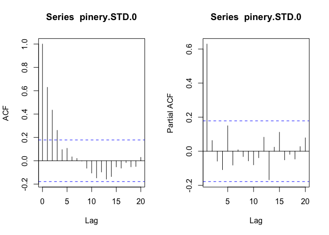

```r
op <- par(no.readonly = TRUE) # Save to reset on exit
par(mfcol=c(1, 2))
acf(pinery.STD.0)
pacf(pinery.STD.0)
```

```r
par(op)
```

We now have the first bit of solid information about the time-series properties of these data, it looks like they fit an AR(1) model.

The easiest way is to use the ar function which fits an autoregressive model and selects the order by AIC.

```r
pinery.ar <- ar(pinery.STD.0)
pinery.ar
```

```
##
## Call:
## ar(x = pinery.STD.0)
##
## Coefficients:
##      1
## 0.6293
##
## Order selected 1  sigma^2 estimated as  0.03543
```

Indeed, ar produces an AR(1) model. We can do the same sort of analysis by automatically fitting an ARMA model using the auto.arima function in the package “forecast”.

```r
pinery.arima <- auto.arima(pinery.STD.0, ic="bic")
summary(pinery.arima)
```

```
## Series: pinery.STD.0
## ARIMA(0,1,1)
##
## Coefficients:
##           ma1
##       -0.3125
## s.e.   0.1021
##
## sigma^2 estimated as 0.03341:  log likelihood=34.11
## AIC=-64.23   AICc=-64.13   BIC=-58.65
##
## Training set error measures:
##                     ME      RMSE       MAE       MPE     MAPE      MASE
## Training set 0.0119641 0.1812632 0.1476532 -1.592693 15.79989 0.9592019
##                    ACF1
## Training set 0.01830801
```

```r
head(residuals(pinery.arima))
```

```
## Time Series:
## Start = 1
## End = 6
## Frequency = 1
## [1]  0.0008669995 -0.0028631781  0.1186317116 -0.1310320127  0.3160561942
## [6]  0.1207643328
```

```r
coef(pinery.arima)
```

```
##        ma1
## -0.3125041
```

```r
acf(residuals(pinery.arima),plot=FALSE)
```

```
##
## Autocorrelations of series 'residuals(pinery.arima)', by lag
##
##      0      1      2      3      4      5      6      7      8      9     10
##  1.000  0.018 -0.033 -0.090 -0.262  0.076 -0.035  0.058  0.041 -0.077 -0.002
##     11     12     13     14     15     16     17     18     19     20
## -0.017  0.148 -0.037 -0.096  0.068 -0.044  0.077 -0.119 -0.149  0.001
```

# 4 Standard Morlet wavelet transform analysis

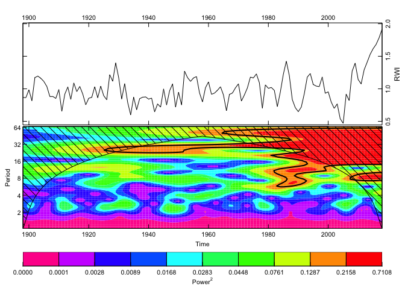

```r
out.wave <- morlet(y1 = pinery.STD.0, x1 = years, p2 = 6, dj = 0.1,
                   siglvl = 0.95)
wavelet.plot(out.wave, useRaster = NA)
```

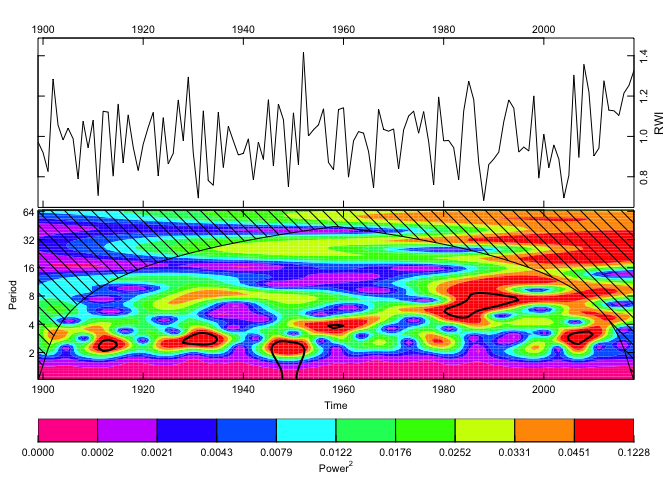

```r
out.wave2 <- morlet(y1 = pinery.RES.0, x1 = years2, p2 = 6, dj = 0.1,
                   siglvl = 0.95)
wavelet.plot(out.wave2, useRaster = NA)
```

# 5 Cross-wavelet Analysis

For cross-wavelet analysis (chronology vs another index such as the PDO index) I used the “WaveletComp” package in R.

# 6 Reproducibility

```r
citation("dplR")
```

```
##
## Bunn AG (2008). "A dendrochronology program library in R (dplR)."
## _Dendrochronologia_, *26*(2), 115-124. ISSN 1125-7865, doi:
## 10.1016/j.dendro.2008.01.002 (URL:
## https://doi.org/10.1016/j.dendro.2008.01.002).
##
## Bunn AG (2010). "Statistical and visual crossdating in R using the dplR
## library." _Dendrochronologia_, *28*(4), 251-258. ISSN 1125-7865, doi:
## 10.1016/j.dendro.2009.12.001 (URL:
## https://doi.org/10.1016/j.dendro.2009.12.001).
##
##   Andy Bunn, Mikko Korpela, Franco Biondi, Filipe Campelo, Pierre
##   Mérian, Fares Qeadan and Christian Zang (2020). dplR:
##   Dendrochronology Program Library in R. R package version 1.7.1.
##   https://CRAN.R-project.org/package=dplR
##
## To see these entries in BibTeX format, use 'print(<citation>,
## bibtex=TRUE)', 'toBibtex(.)', or set
## 'options(citation.bibtex.max=999)'.
```

```r
Sys.time()
```

```
## [1] "2020-06-05 15:42:49 PDT"
```

```r
git2r::repository()
```

```
## Local:    master /Users/JenBaron/Documents/UWO/UWO NSERC/Statistical Analysis/Dendrochronology/Dendrochronology in R/Dendrochronology_in_R
## Remote:   master @ origin (https://github.com/JenBaron/Dendrochronology_in_R.git)
## Head:     [f63e16a] 2020-06-02: Residual chronology
```